# PubMed Counts of Articles

Joy Payton

2/18/2022

## Overview

What are the rates of publication of papers on various topics?

### R Markdown

This is an R Markdown File, which is a way to interlace three things:

- R (or other!) programming language
- Statistical or scientific reasoning about the code we write, and
- The output of R code

… all in one place. You can export this interweaving of human and computer language as well as the code output to various formats – pdf, Microsoft Word, or html. Are you new to R Markdown? Here are some great resources:

- R Markdown was developed by RStudio. Read their descriptions and examples on [their site](https://rmarkdown.rstudio.com/).
- The RStudio gurus wrote a great book about it – [check it out](https://bookdown.org/yihui/rmarkdown/)!

## Load Packages

Here we add the packages we’ll use. `tidyverse` helps reshape data, `easyPubMed` simplifies the use of the PubMed API, and `printr` allows us to show data frames more attractively.

```r
library(tidyverse)
library(easyPubMed)
library(printr)
```

## A Single Search

The results tell me the overall count (600) and give me the first few (from `RetStart` to `RetMax`) matching article IDs.

```r
results <- get_pubmed_ids("2015[Date - Publication] AND medicine disparity")
results
```

```
## $Count
## [1] "600"
##
## $RetMax
## [1] "20"
##
## $RetStart
## [1] "0"
##
## $QueryKey
## [1] "1"
##
## $WebEnv
## [1] "MCID_6300112ca2d6ec2add42c38a"
##
## $IdList
## $IdList$Id
## [1] "28149430"
##
## $IdList$Id
## [1] "27927559"
##
## $IdList$Id
## [1] "26289634"
##
## $IdList$Id
## [1] "26489876"
##
## $IdList$Id
## [1] "27330533"
##
## $IdList$Id
## [1] "27294764"
##
## $IdList$Id
## [1] "27294752"
##
## $IdList$Id
## [1] "27271069"
##
```

[output cut: 35 more lines]

```
##
##
## $TranslationSet
## $TranslationSet$From
## [1] "medicine"
##
## $TranslationSet$To
## [1] "\"medicine\"[MeSH Terms] OR \"medicine\"[All Fields]"
##
##
## $QueryTranslation
## [1] "2015[Date - Publication] AND ((\"medicine\"[MeSH Terms] OR \"medicine\"[All Fields]) AND disparity[All Fields])"
##
## $OriginalQuery
## [1] "2015[Date+-+Publication]+AND+medicine+disparity"
```

I can also extract just the count of articles:

```r
results$Count
```

```
## [1] "600"
```

But I don’t want to do that for every combination of year and search term, to get the count of articles!

I’ll start by creating my search terms.

## Create Search Terms

We’ll make the combinatoric using `expand_grid()` from `tidyverse`.

```r
years <- c(2012:2023)

terms <- c(
  'medicine disparity',
  'medicine racism',
  'medicine racial bias')

search_terms <- expand_grid("year" = years,
                       "term" = terms)
```

Let’s peek!

```r
head(search_terms, 10)
```

| year | term |
| --- | --- |
| 2012 | medicine disparity |
| 2012 | medicine racism |
| 2012 | medicine racial bias |
| 2013 | medicine disparity |
| 2013 | medicine racism |
| 2013 | medicine racial bias |
| 2014 | medicine disparity |
| 2014 | medicine racism |
| 2014 | medicine racial bias |
| 2015 | medicine disparity |

OK, now we’ll pad those search terms with the text that the API requires:

```r
search_terms <- search_terms %>%
  mutate(final = paste(year,
                       "[Date - Publication]",
                       " AND ",
                       term,
                       sep = ""
                       ))
```

And let’s look again:

```r
head(search_terms, 20)
```

| year | term | final |
| --- | --- | --- |
| 2012 | medicine disparity | 2012[Date - Publication] AND medicine disparity |
| 2012 | medicine racism | 2012[Date - Publication] AND medicine racism |
| 2012 | medicine racial bias | 2012[Date - Publication] AND medicine racial bias |
| 2013 | medicine disparity | 2013[Date - Publication] AND medicine disparity |
| 2013 | medicine racism | 2013[Date - Publication] AND medicine racism |
| 2013 | medicine racial bias | 2013[Date - Publication] AND medicine racial bias |
| 2014 | medicine disparity | 2014[Date - Publication] AND medicine disparity |
| 2014 | medicine racism | 2014[Date - Publication] AND medicine racism |
| 2014 | medicine racial bias | 2014[Date - Publication] AND medicine racial bias |
| 2015 | medicine disparity | 2015[Date - Publication] AND medicine disparity |
| 2015 | medicine racism | 2015[Date - Publication] AND medicine racism |
| 2015 | medicine racial bias | 2015[Date - Publication] AND medicine racial bias |
| 2016 | medicine disparity | 2016[Date - Publication] AND medicine disparity |
| 2016 | medicine racism | 2016[Date - Publication] AND medicine racism |
| 2016 | medicine racial bias | 2016[Date - Publication] AND medicine racial bias |
| 2017 | medicine disparity | 2017[Date - Publication] AND medicine disparity |
| 2017 | medicine racism | 2017[Date - Publication] AND medicine racism |
| 2017 | medicine racial bias | 2017[Date - Publication] AND medicine racial bias |
| 2018 | medicine disparity | 2018[Date - Publication] AND medicine disparity |
| 2018 | medicine racism | 2018[Date - Publication] AND medicine racism |

## Search in PubMed

Now we’ll make a short function that returns the count of results for a given term:

```r
count_results <- function(term) {
  results <- get_pubmed_ids(term)
  count <- as.integer(results$Count)
  return(count)
}
```

And now we’ll use that function to populate a new column. Note that we’re using an `lapply` function that lets us put a pause between searches in order to not go over the “anonymous” API rate supported by PubMed.

```r
search_terms <- search_terms %>%
  mutate(num_results = lapply(final, function(f) {
    Sys.sleep(0.5)
    count_results(f)
    }))
```

## Visualize the Data

`ggplot` lets us take a look at our results graphically:

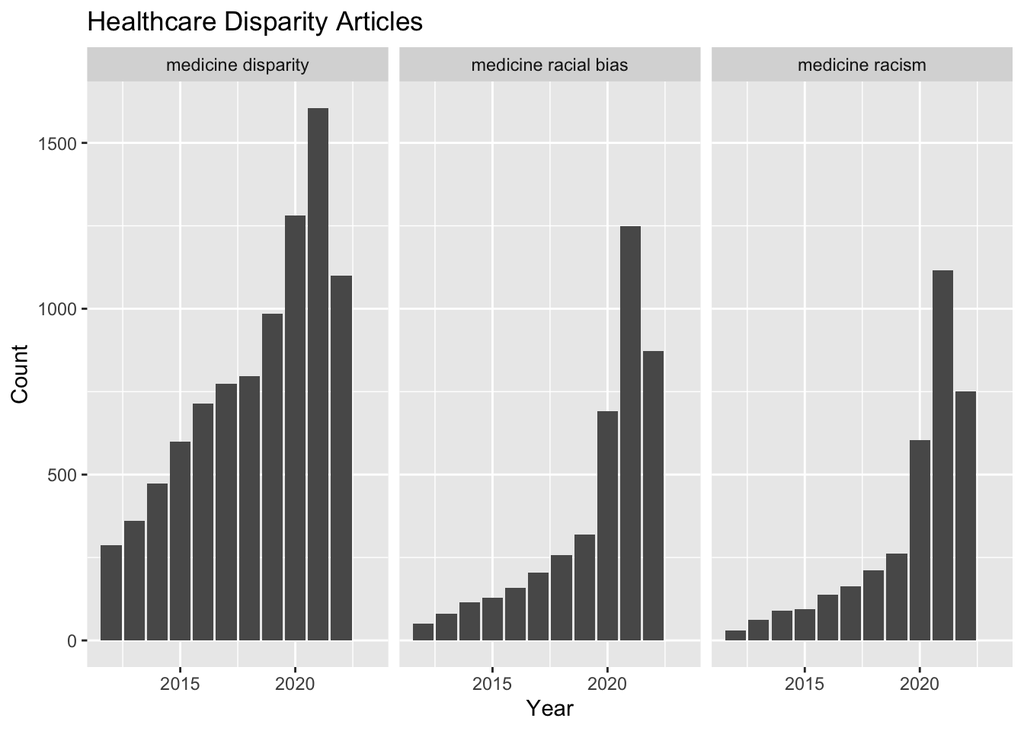

```r
ggplot(search_terms,
       aes(x=year, y=num_results)) +
  geom_col() +
  facet_wrap(term ~ .) +
  xlab("Year") +
  ylab("Count") +
  ggtitle("Healthcare Disparity Articles")
```